# Prediction of Well Performed Exercise using Data Science

Tomas Mawyin

## Executive Summary

The objective of this project is to use machine learning algorithms to determine how well an exercise is performed. The data was collected in a study where participants were asked to perform weight lifting exercises in correct and incorrect manners. Sensors were used to measure several arm, forearm, body, and dumbbell positions and accelerations. These measurements are used in machine learning algorithms to classify the exercise. In this report, decision trees and random forest are used to perform the classification. Initially, a exploratory analysis is presented followed by some preprocessing of the data. Finally, the algorithms are presented with a discussion of their accuracy and measurements of error.

## Exploratory Data Analysis and Preprocessing

To start the project it is necessary to download the data and read the files. To avoid any issues when reading the data, we will take care of NA values as well as missing fields.

```r
# URL for the training and testing sets
train.url <- "https://d396qusza40orc.cloudfront.net/predmachlearn/pml-training.csv"
test.url <- "https://d396qusza40orc.cloudfront.net/predmachlearn/pml-testing.csv"

# Downloading the files
download.file(train.url, destfile="pml-training.csv", method="libcurl")
download.file(test.url, destfile="pml-testing.csv", method="libcurl")

# Now we can read the files
train.data <- read.csv("pml-training.csv", stringsAsFactors=FALSE, na.strings=c("","NA","#DIV/0"))
test.data <- read.csv("pml-testing.csv", stringsAsFactors=FALSE, na.strings=c("","NA","#DIV/0"))
```

Part of the exploratory step is to clean the data as much as possible. Since the fields with NA do not provide much information as predictors, the first step is to recognize which columns contain NAs. Once the columns with missing values is determine it is possible to remove these columns from the training and testing sets.

```r
# We know a lot of columns that contain NAs. Let's separate the NA columns
na.cols <- sapply(train.data, function(x) any(is.na(x)))

# We know that the test and the training set have the same variables.
train.data <- train.data[,!na.cols]
test.data <- test.data[,!na.cols]
```

For the final cleaning step, we can remove those columns that do not act as predictors; that is, the first seven columns in the data which represent the name of the participant and time-stamp information.

```r
# We can also remove the first 7 columns, since they are not predictors
train.data <- train.data[,-seq(1,7)]
test.data <- test.data[,-seq(1,7)]
testing <- test.data[,-length(test.data)]

# Let's get the final dimensions of the training data set
dim(train.data)
```

```
## [1] 19622    53
```

```r
str(train.data)
```

```
## 'data.frame':    19622 obs. of  53 variables:
##  $ roll_belt           : num  1.41 1.41 1.42 1.48 1.48 1.45 1.42 1.42 1.43 1.45 ...
##  $ pitch_belt          : num  8.07 8.07 8.07 8.05 8.07 8.06 8.09 8.13 8.16 8.17 ...
##  $ yaw_belt            : num  -94.4 -94.4 -94.4 -94.4 -94.4 -94.4 -94.4 -94.4 -94.4 -94.4 ...
##  $ total_accel_belt    : int  3 3 3 3 3 3 3 3 3 3 ...
##  $ gyros_belt_x        : num  0 0.02 0 0.02 0.02 0.02 0.02 0.02 0.02 0.03 ...
##  $ gyros_belt_y        : num  0 0 0 0 0.02 0 0 0 0 0 ...
##  $ gyros_belt_z        : num  -0.02 -0.02 -0.02 -0.03 -0.02 -0.02 -0.02 -0.02 -0.02 0 ...
##  $ accel_belt_x        : int  -21 -22 -20 -22 -21 -21 -22 -22 -20 -21 ...
##  $ accel_belt_y        : int  4 4 5 3 2 4 3 4 2 4 ...
##  $ accel_belt_z        : int  22 22 23 21 24 21 21 21 24 22 ...
##  $ magnet_belt_x       : int  -3 -7 -2 -6 -6 0 -4 -2 1 -3 ...
##  $ magnet_belt_y       : int  599 608 600 604 600 603 599 603 602 609 ...
##  $ magnet_belt_z       : int  -313 -311 -305 -310 -302 -312 -311 -313 -312 -308 ...
##  $ roll_arm            : num  -128 -128 -128 -128 -128 -128 -128 -128 -128 -128 ...
```

[output cut: 39 more lines]

The training and testing sets are now clean, they contain the required predictors that can be used in the machine learning algorithms. However, before applying the algorithms we will perform some preprocessing steps.

The first thing to do when preprocessing any data is to investigate zero variance predictors. The following code will count the number of zero variance predictors in the training data set.

```r
sum(nearZeroVar(train.data,saveMetrics = TRUE)[,3])
```

```
## [1] 0
```

Since the data is well suited for the analysis, it would be appropriate to visualize some of the data to get some insights on the algorithms that could be used. Just to get an idea, this report shows two basic plots where two predictors from the training set are shown. The colour of the plot represent the labelled data in the training set.

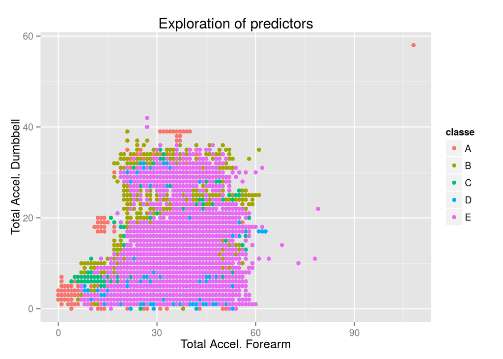

```r
ggplot(data=train.data, aes(total_accel_forearm, total_accel_dumbbell)) +
    geom_point(aes(color=classe)) +
    labs(title = "Exploration of predictors") +
    labs(x = "Total Accel. Forearm", y = "Total Accel. Dumbbell")
```

[figure not shown]

```r
ggplot(data=train.data, aes(roll_arm, yaw_dumbbell)) +
    geom_point(aes(color=classe)) +
    labs(title = "Exploration of predictors") +
    labs(x = "Roll Forearm", y = "Yaw Dumbbell")
```

Based on the above plots, we know that we need to use an algorithm that would handle non-linearity in the data. The following step is to present the algorithms and their statistics.

## Machine Learning Algorithms

The first step in any machine learning algorithm is to split the data to obtain a cross-validation data set. This set will allow us to test the predictions using labelled data and make comparisons to check the accuracy of the algorithm. The training set will be split using a 60/40 partition. We can also check if the training set has balanced classes.

```r
set.seed(159753)
data.split <- createDataPartition(train.data$classe, p=0.60, list=FALSE)
training <- train.data[data.split,]
cross.val <- train.data[-data.split,]

# Let's see if there is an unbalance in the classes
table(training$classe)
```

```
##
##    A    B    C    D    E
## 3348 2279 2054 1930 2165
```

### Decision Trees

A decision tree is useful in this case because we can split the data based on some of the predictors to make decisions on each of the classes. The following code will use the training set to train a decision tree and the final tree will be plotted.

```r
# Let's train the model using a decision tree. We will use tuneLength=30 to
# investigate more models
model.tree <- train(classe ~ ., data = training, method = "rpart",
                    preProcess=c("center", "scale"), tuneLength = 30)
model.tree$finalModel
```

```
## n= 11776
##
## node), split, n, loss, yval, (yprob)
##       * denotes terminal node
##
##     1) root 11776 8428 A (0.28 0.19 0.17 0.16 0.18)
##       2) roll_belt< 1.054642 10791 7453 A (0.31 0.21 0.19 0.18 0.11)
##         4) pitch_forearm< -1.59283 938    4 A (1 0.0043 0 0 0) *
##         5) pitch_forearm>=-1.59283 9853 7449 A (0.24 0.23 0.21 0.2 0.12)
##          10) magnet_dumbbell_y< 0.6694155 8335 5979 A (0.28 0.18 0.24 0.19 0.11)
##            20) roll_forearm< 0.8267261 5202 3095 A (0.41 0.17 0.19 0.17 0.064)
##              40) magnet_dumbbell_z< -0.5286253 1743  571 A (0.67 0.21 0.014 0.071 0.037)
##                80) roll_forearm>=-1.555969 1461  318 A (0.78 0.17 0.015 0.021 0.0089)
##                 160) roll_forearm< 0.7251383 1286  191 A (0.85 0.11 0.017 0.01 0.0086) *
##                 161) roll_forearm>=0.7251383 175   67 B (0.27 0.62 0 0.097 0.011) *
##                81) roll_forearm< -1.555969 282  176 B (0.1 0.38 0.0071 0.33 0.18)
##                 162) gyros_arm_y>=1.455033 99   25 B (0 0.75 0 0 0.25) *
##                 163) gyros_arm_y< 1.455033 183   90 D (0.16 0.17 0.011 0.51 0.15) *
##              41) magnet_dumbbell_z>=-0.5286253 3459 2503 C (0.27 0.16 0.28 0.22 0.078)
##                82) yaw_belt>=1.8869 451   63 A (0.86 0.064 0 0.071 0.0044)
##                 164) pitch_belt>=-2.025229 408   20 A (0.95 0.049 0 0 0) *
##                 165) pitch_belt< -2.025229 43   11 D (0 0.21 0 0.74 0.047) *
##                83) yaw_belt< 1.8869 3008 2052 C (0.18 0.17 0.32 0.24 0.089)
##                 166) accel_dumbbell_y>=-1.151024 2586 1880 D (0.21 0.19 0.23 0.27 0.097)
##                   332) pitch_belt< -1.931283 292   56 B (0.01 0.81 0.13 0.024 0.031) *
##                   333) pitch_belt>=-1.931283 2294 1595 D (0.24 0.12 0.24 0.3 0.11)
##                     666) roll_belt>=0.9749413 536  209 C (0.36 0.017 0.61 0.0075 0.0037)
##                      1332) magnet_belt_z< 0.3515086 178    7 A (0.96 0 0.028 0 0.011) *
##                      1333) magnet_belt_z>=0.3515086 358   36 C (0.064 0.025 0.9 0.011 0) *
##                     667) roll_belt< 0.9749413 1758 1063 D (0.2 0.15 0.13 0.4 0.14)
##                      1334) pitch_belt>=0.03644128 1112  846 A (0.24 0.22 0.13 0.22 0.19)
##                        2668) accel_dumbbell_z< 0.636776 728  476 A (0.35 0.16 0.2 0.26 0.036)
##                          5336) yaw_forearm>=-1.096539 526  274 A (0.48 0.2 0.21 0.076 0.038)
##                           10672) magnet_forearm_z>=-1.390878 337   92 A (0.73 0.15 0.0089 0.092 0.027)
##                             21344) magnet_dumbbell_x>=-0.6612016 296   53 A (0.82 0.057 0.01 0.1 0.01) *
##                             21345) magnet_dumbbell_x< -0.6612016 41    9 B (0.049 0.78 0 0.024 0.15) *
##                           10673) magnet_forearm_z< -1.390878 189   84 C (0.037 0.3 0.56 0.048 0.058)
##                             21346) accel_dumbbell_y< -0.7909339 71   14 B (0 0.8 0.18 0 0.014) *
##                             21347) accel_dumbbell_y>=-0.7909339 118   26 C (0.059 0 0.78 0.076 0.085) *
##                          5337) yaw_forearm< -1.096539 202   50 D (0 0.035 0.18 0.75 0.03) *
```

[output cut: 35 more lines]

```
##                87) accel_forearm_x< -0.2034921 475  139 D (0.067 0.13 0.029 0.71 0.065)
##                 174) accel_dumbbell_z>=0.7605476 56    2 B (0 0.96 0 0.018 0.018) *
##                 175) accel_dumbbell_z< 0.7605476 419   84 D (0.076 0.019 0.033 0.8 0.072) *
##          11) magnet_dumbbell_y>=0.6694155 1518  725 B (0.032 0.52 0.039 0.22 0.19)
##            22) total_accel_dumbbell>=-0.7958493 1091  369 B (0.044 0.66 0.053 0.025 0.22)
##              44) roll_belt>=-1.034795 922  200 B (0.052 0.78 0.063 0.029 0.073)
##                88) magnet_belt_y>=-0.2092324 873  151 B (0.055 0.83 0.066 0.031 0.021) *
##                89) magnet_belt_y< -0.2092324 49    0 E (0 0 0 0 1) *
##              45) roll_belt< -1.034795 169    0 E (0 0 0 0 1) *
##            23) total_accel_dumbbell< -0.7958493 427  120 D (0 0.17 0.0023 0.72 0.11)
##              46) yaw_belt< 0.0895607 66    0 B (0 1 0 0 0) *
##              47) yaw_belt>=0.0895607 361   54 D (0 0.014 0.0028 0.85 0.13)
##                94) roll_belt< 0.9111806 315    8 D (0 0.016 0.0032 0.97 0.0063) *
##                95) roll_belt>=0.9111806 46    0 E (0 0 0 0 1) *
##       3) roll_belt>=1.054642 985   10 E (0.01 0 0 0 0.99) *
```

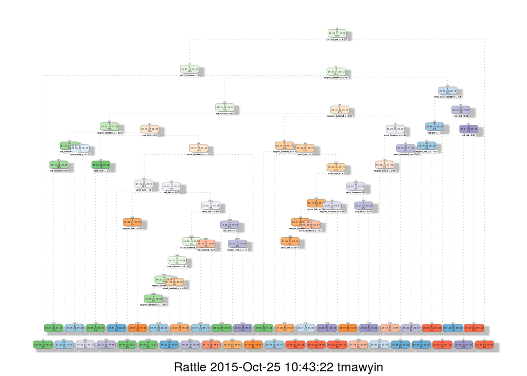

```r
fancyRpartPlot(model.tree$finalModel)
```

The final tree is a bit complicated, but we can look at the statistics of the model by looking at the cross-validation data set and checking the confusion matrix which will indicate how off we are in the predictions

```r
#How do we do on the cross-validation set
predict.cv <- predict(model.tree, newdata = cross.val)
confusionMatrix(predict.cv, cross.val$classe)
```

```
## Confusion Matrix and Statistics
##
##           Reference
## Prediction    A    B    C    D    E
##          A 1985  146   20   38   14
##          B  117 1138  147   58   91
##          C   42   93 1099   78   82
##          D   46   50   58 1014   56
##          E   42   91   44   98 1199
##
## Overall Statistics
##
##                Accuracy : 0.8202
##                  95% CI : (0.8115, 0.8286)
##     No Information Rate : 0.2845
##     P-Value [Acc > NIR] : < 2.2e-16
##
##                   Kappa : 0.7726
##  Mcnemar's Test P-Value : 5.361e-10
##
## Statistics by Class:
##
##                      Class: A Class: B Class: C Class: D Class: E
## Sensitivity            0.8893   0.7497   0.8034   0.7885   0.8315
## Specificity            0.9612   0.9347   0.9545   0.9680   0.9571
## Pos Pred Value         0.9010   0.7337   0.7884   0.8284   0.8134
## Neg Pred Value         0.9562   0.9396   0.9583   0.9589   0.9619
## Prevalence             0.2845   0.1935   0.1744   0.1639   0.1838
## Detection Rate         0.2530   0.1450   0.1401   0.1292   0.1528
## Detection Prevalence   0.2808   0.1977   0.1777   0.1560   0.1879
## Balanced Accuracy      0.9253   0.8422   0.8789   0.8782   0.8943
```

The accuracy of the decision tree is approximately 80%. There is a large error in the cross-validation set. This will imply a larger error in the testing set. Since the accuracy can be improved, we will not apply this algorithm on the testing set.

### Random Forest

Similar to the decision tree, we can apply a “stronger” algorithm such as random forest to make predictions. Random forest work by combining the output of various decision trees so we expect the results to be more accurate. The following code will make predictions on the cross-validation data set and will output the statistics of the model.

```r
model.forest <- train(classe ~ ., data = training, method = 'rf',
                      trControl=trainControl(method="cv",number=5),
                      preProcess=c("center", "scale"))
predict.forest <- predict(model.forest, newdata = cross.val)
confusionMatrix(predict.forest, cross.val$classe)
```

```
## Confusion Matrix and Statistics
##
##           Reference
## Prediction    A    B    C    D    E
##          A 2228   22    0    0    0
##          B    1 1492   16    0    1
##          C    2    3 1344   23    4
##          D    0    1    8 1261    3
##          E    1    0    0    2 1434
##
## Overall Statistics
##
##                Accuracy : 0.9889
##                  95% CI : (0.9863, 0.9911)
##     No Information Rate : 0.2845
##     P-Value [Acc > NIR] : < 2.2e-16
##
##                   Kappa : 0.986
##  Mcnemar's Test P-Value : NA
##
## Statistics by Class:
##
##                      Class: A Class: B Class: C Class: D Class: E
## Sensitivity            0.9982   0.9829   0.9825   0.9806   0.9945
## Specificity            0.9961   0.9972   0.9951   0.9982   0.9995
## Pos Pred Value         0.9902   0.9881   0.9767   0.9906   0.9979
## Neg Pred Value         0.9993   0.9959   0.9963   0.9962   0.9988
## Prevalence             0.2845   0.1935   0.1744   0.1639   0.1838
## Detection Rate         0.2840   0.1902   0.1713   0.1607   0.1828
## Detection Prevalence   0.2868   0.1925   0.1754   0.1622   0.1832
## Balanced Accuracy      0.9971   0.9900   0.9888   0.9894   0.9970
```

We can see that this model is almost 100% accurate. Althought we know that this accuracy was achieved on the cross-validation set, we can expect the testing set to have a larger error (less accuracy), but for the predictions of this kind this is a great accuracy and we would expect to achieve good predictions on similar data. It should also be noted that the gain in accuracy is offset by an increase in computational speed as it takes more time to execute a random forest algorithm than a decision tree. Finally, we can make predictions on the testing set and save the results.

```r
final.prediction <- predict(model.forest, newdata = testing)
final.prediction
```

```
##  [1] B A B A A E D B A A B C B A E E A B B B
## Levels: A B C D E
```